# Classification Models

João Victor

2022-10-31

### Load the libraries

```r
library(tidyverse)
library(summarytools)
library(RColorBrewer)
library(gridExtra)
library(e1071)
library(caTools)
library(caret)
library(class)
library(rpart)
library(randomForest)
library(h2o)
library(xgboost)
```

### Load the data

```r
train = read.csv('train.csv' ,na.strings = c("", "NA"))
test = read.csv('test.csv', na.strings = c("", "NA"))
test_values = read.csv('sample_submission.csv')
test$Transported = NA
```

### Data Description

##### **PassengerId**

A unique id for each passenger, Each id takes the form gggg_pp where gggg indicates a group the passenger is travelling with and pp is the number within the group. People in a group are often family members, but no always.

##### **HomePlanet**

The planet the passenger departed from, typically their planet of permanent residence.

##### **CryoSleep**

Indicates whether the passenger elected to be put into suspended animation for the duration of the voyage. Passengers in cryosleep are confined to their cabins.

##### **Cabin**

The cabin number where the passenger is staying. Takes the form deck/num/side, where side can be either P for Port or S for Starboard.

##### **Destination**

The planet the passenger will be debarking to.

##### **Age**

The age of the passenger.

##### **VIP**

Whether the passenger has paid for special VIP service during the voyage.

##### **RoomService, FoodCourt, ShoppingMall, Spa, VRDeck**

Amount the passenger has billed at each of the Spaceship Titanic’s many luxury amenities.

##### **Name**

The first and last names of the passenger.

##### **Transported**

Whether the passenger was transported to another dimension. This is the target, the column you are trying to predict.

- I’ll merge the two datasets to make the cleaning and data preprocessing in both at the same time.

```r
merged = rbind(train, test)
```

First we need to know the number of missing values.

```r
NAcol = colnames(merged)[colSums(is.na(merged))>0]
sort(colSums(sapply(merged[NAcol], is.na)), decreasing = T)
```

```
##  Transported    CryoSleep ShoppingMall        Cabin          VIP         Name
##         4277          310          306          299          296          294
##    FoodCourt   HomePlanet          Spa  Destination          Age       VRDeck
##          289          288          284          274          270          268
##  RoomService
##          263
```

### Fix it

**CryoSleep**

```r
merged$CryoSleep[is.na(merged$CryoSleep)] = names(sort(-table(merged$CryoSleep))) [1]
```

**ShoppingMall**

```r
merged$ShoppingMall[is.na(merged$ShoppingMall)] = median(merged$ShoppingMall, na.rm = T)
```

**Cabin**  
When we analyze the Cabin column, it’s difficult not to drop the variable, but if we check the description of this variable we can see that the first letter means the deck of this passenger, and the last letter means what is the side of the cabin (Port - left, Starboard - right). I’ll then, create two new variables called CabinDeck and CabinSide, before handle the missing values.

```r
CabinDeck = merged$Cabin %>% str_replace("/.*", "")
merged$CabinDeck = CabinDeck

CabinSide = merged$Cabin %>% str_replace(".*/", "")
merged$CabinSide = CabinSide
```

**CabinDeck**

```r
merged$CabinDeck[is.na(merged$CabinDeck)] = median(merged$CabinDeck, na.rm = T)
```

**CabinSide**

```r
merged$CabinSide[is.na(merged$CabinSide)] = median(merged$CabinSide, na.rm = T)
```

**CabinShared** I’ll also create a variable called CabinShared for duplicated Cabin values (including deck/num/side). I could also create a variable for family members based on surname. I actually created but was too similar of CabinShared, so i decided to drop.

```r
merged$CabinShared = merged$Cabin %in% unique(merged$Cabin[duplicated(merged$Cabin, incomparables = NA)])
```

We don’t need the Cabin columns anymore, so it’s time to drop it.

```r
merged$Cabin = NULL
merged$Name = NULL
```

**VIP**

```r
merged$VIP[is.na(merged$VIP)] = names(sort(-table(merged$VIP))) [1]
```

**FoodCourt**

```r
merged$FoodCourt[is.na(merged$FoodCourt)] = median(merged$FoodCourt, na.rm = T)
```

**HomePlanet**

```r
merged$HomePlanet[is.na(merged$HomePlanet)] = names(sort(-table(merged$HomePlanet))) [1]
```

**Spa**

```r
merged$Spa[is.na(merged$Spa)] = median(merged$Spa, na.rm = T)
```

**Destination**

```r
merged$Destination[is.na(merged$Destination)] = names(sort(-table(merged$Destination))) [1]
```

**Age**

```r
set.seed(1)
merged$Age[is.na(merged$Age)] = round(runif(sum(is.na(merged$Age)), min = 0, max = 79),0)
```

**VRDeck**

```r
merged$VRDeck[is.na(merged$VRDeck)] = median(merged$VRDeck, na.rm = T)
```

**RoomService**

```r
merged$RoomService[is.na(merged$RoomService)] = median(merged$RoomService, na.rm = T)
```

Check NA values again.

```r
NAcol = colnames(merged)[colSums(is.na(merged))>0]
sort(colSums(sapply(merged[NAcol], is.na)), decreasing = T)
```

```
## Transported
##        4277
```

Only Transported column still have NA values, so the data is almost ready.

### EDA

```r
train_x = merged[1:8693, ]
test_x = merged[8694:12970, ]
```

```r
my_colors <- RColorBrewer::brewer.pal(4, "Set1")[2:4]
```

**HomePlanet**

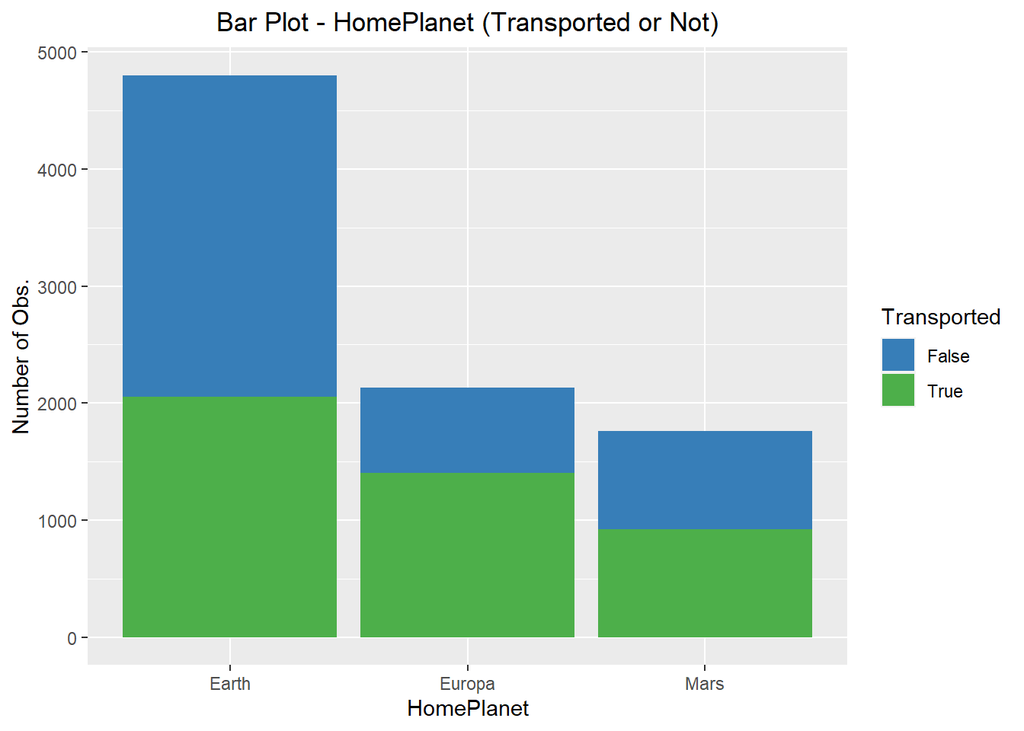

```r
ggplot(train_x, aes(HomePlanet, fill = Transported)) +
  geom_bar() +
  scale_fill_manual(values = my_colors, labels = c('False', 'True')) +
  ggtitle('Bar Plot - HomePlanet (Transported or Not)') + theme(plot.title = element_text(hjust = 0.5)) +
  ylab('Number of Obs.')
```

**CryoSleep**

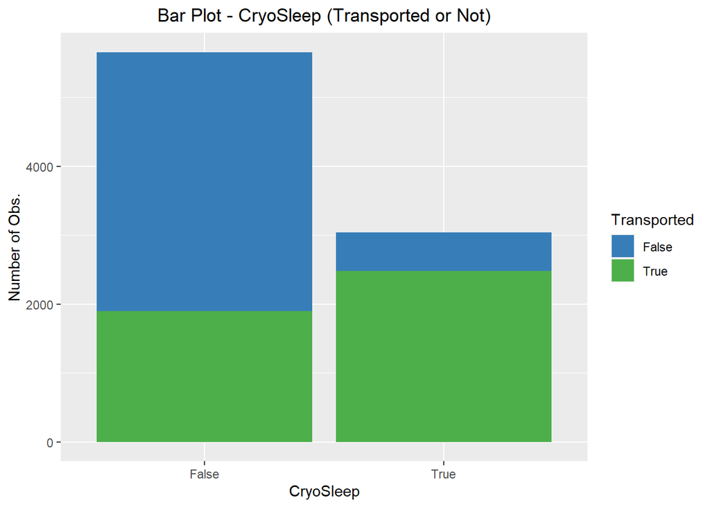

```r
ggplot(train_x, aes(CryoSleep, fill = Transported)) +
  geom_bar() +
  scale_fill_manual(values = my_colors, labels = c('False', 'True')) +
  ggtitle('Bar Plot - CryoSleep (Transported or Not)') + theme(plot.title = element_text(hjust = 0.5)) +
  ylab('Number of Obs.')
```

We can see that most of the passengers who chose the CryoSleep didn’t survived. Trying to use the logic here, maybe this happened because if they were asleep, they couldn’t run or do whatever it was possible to avoid the Transport.

**Destination**

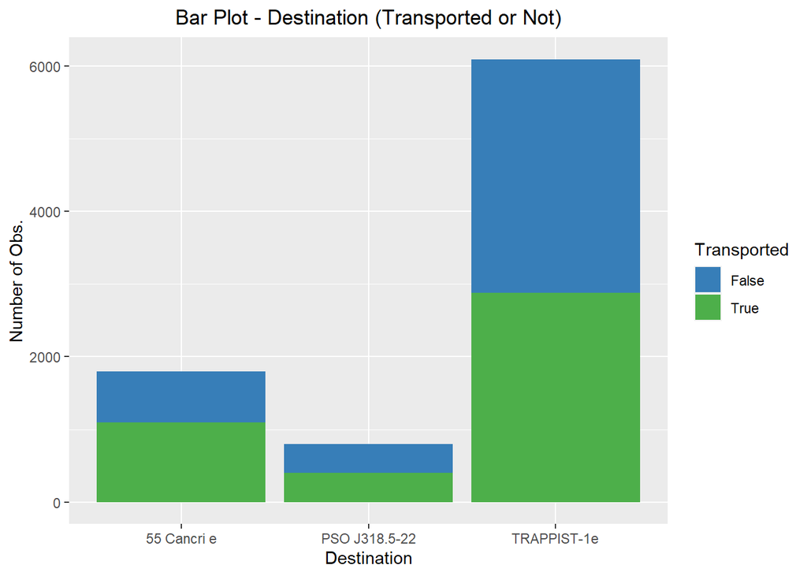

```r
ggplot(train_x, aes(Destination, fill = Transported)) +
  geom_bar() +
  scale_fill_manual(values = my_colors, labels = c('False', 'True')) +
  ggtitle('Bar Plot - Destination (Transported or Not)') + theme(plot.title = element_text(hjust = 0.5)) +
  ylab('Number of Obs.')
```

**Age**

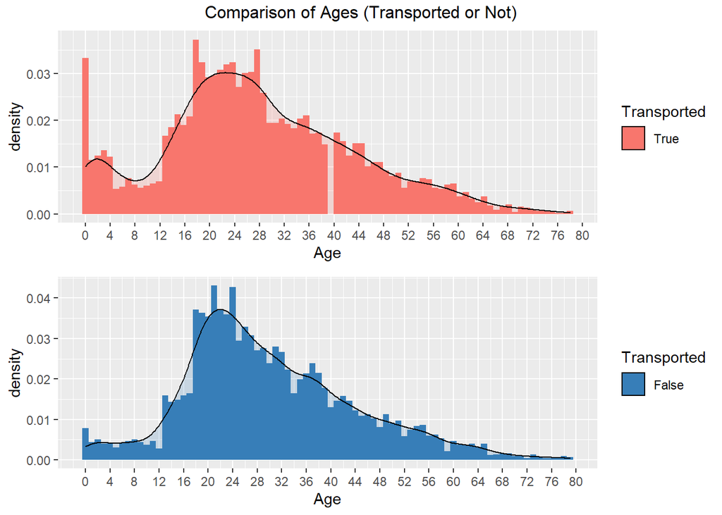

```r
TransportedF = train_x %>% filter(Transported == 'False')
TransportedT = train_x %>% filter(Transported == 'True')

TplotT = ggplot(TransportedT, aes(Age, fill = Transported)) +
  geom_histogram(aes(y = ..density..), bins = 80) +
  geom_density(alpha = 0.2) +
  scale_x_continuous(breaks = seq(0, 80, by = 4))

TplotF = ggplot(TransportedF, aes(Age, fill = Transported)) +
  geom_histogram(aes(y = ..density..), bins = 80) + scale_fill_manual(values = my_colors) +
  geom_density(alpha = 0.2) +
  scale_x_continuous(breaks = seq(0, 80, by = 4))

grid.arrange(TplotT, TplotF, top = 'Comparison of Ages (Transported or Not)')
```

**VIP**

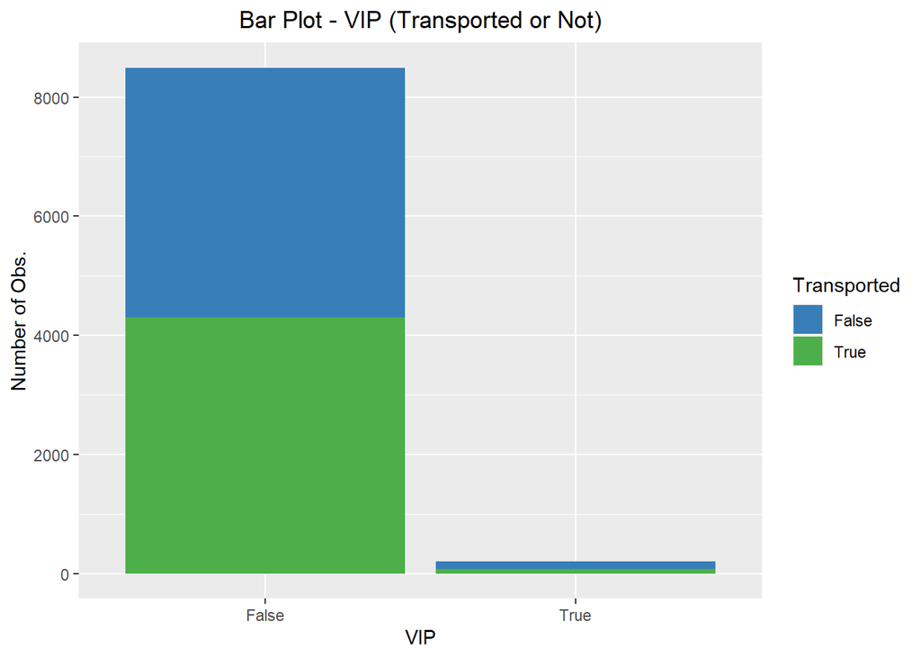

```r
ggplot(train_x, aes(VIP, fill = Transported)) +
  geom_bar() +
  scale_fill_manual(values = my_colors, labels = c('False', 'True')) +
  ggtitle('Bar Plot - VIP (Transported or Not)') + theme(plot.title = element_text(hjust = 0.5)) +
  ylab('Number of Obs.')
```

**CabinDeck**

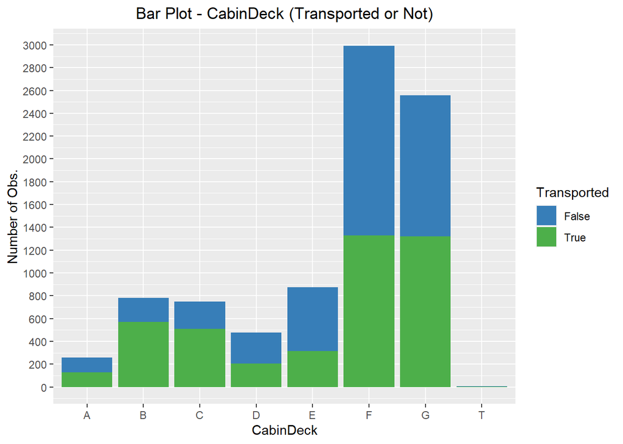

```r
ggplot(train_x, aes(CabinDeck, fill = Transported)) +
  geom_bar() +
  scale_fill_manual(values = my_colors, labels = c('False', 'True')) +
  ggtitle('Bar Plot - CabinDeck (Transported or Not)') + theme(plot.title = element_text(hjust = 0.5)) +
  ylab('Number of Obs.') +
  scale_y_continuous(breaks = seq(0, 3200, by = 200))
```

**CabinSide**

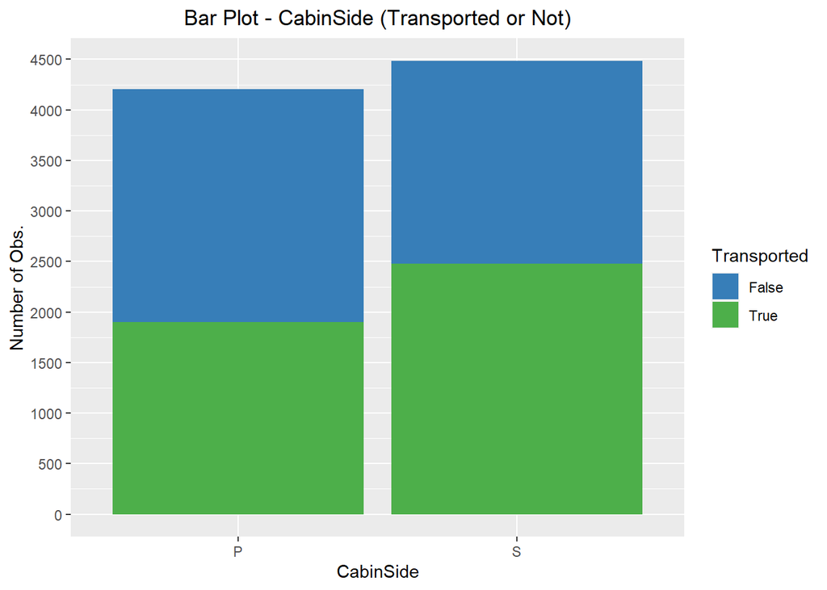

```r
ggplot(train_x, aes(CabinSide, fill = Transported)) +
  geom_bar() +
  scale_fill_manual(values = my_colors, labels = c('False', 'True')) +
  ggtitle('Bar Plot - CabinSide (Transported or Not)') + theme(plot.title = element_text(hjust = 0.5)) +
  ylab('Number of Obs.') +
  scale_y_continuous(breaks = seq(0, 5000, by = 500))
```

**CabinShared**

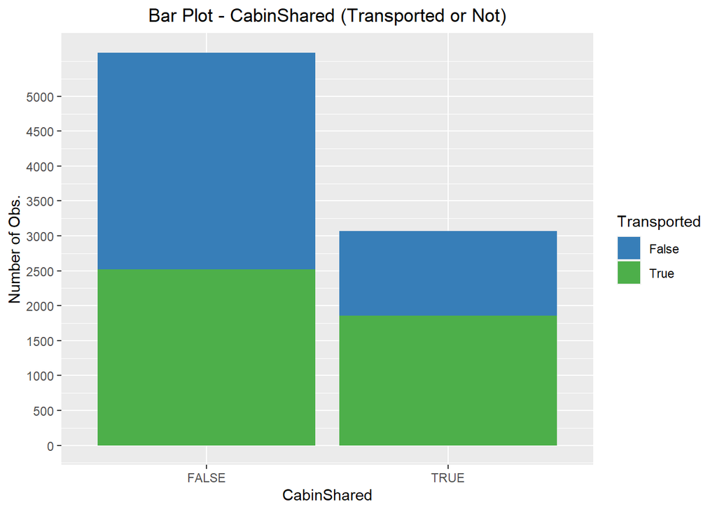

```r
ggplot(train_x, aes(CabinShared, fill = Transported)) +
  geom_bar() +
  scale_fill_manual(values = my_colors, labels = c('False', 'True')) +
  ggtitle('Bar Plot - CabinShared (Transported or Not)') + theme(plot.title = element_text(hjust = 0.5)) +
  ylab('Number of Obs.') +
  scale_y_continuous(breaks = seq(0, 5000, by = 500))
```

### Tables

Now instead of use plots to see the behavior of some variables, i’ll use tables.

**HomePlanet**

```r
ctable(train_x$HomePlanet, train_x$Transported,  dnn = c('HomePlanet', 'Transported'))
```

```
## Cross-Tabulation, Row Proportions
## HomePlanet * Transported
## Data Frame: train_x
##
## ------------ ------------- -------------- -------------- ---------------
##                Transported          False           True           Total
##   HomePlanet
##        Earth                 2749 (57.2%)   2054 (42.8%)   4803 (100.0%)
##       Europa                  727 (34.1%)   1404 (65.9%)   2131 (100.0%)
##         Mars                  839 (47.7%)    920 (52.3%)   1759 (100.0%)
##        Total                 4315 (49.6%)   4378 (50.4%)   8693 (100.0%)
## ------------ ------------- -------------- -------------- ---------------
```

Most of the passengers of Europa and Mars went Transported and 57% of the passengers of Earth didn’t Transported.

**CryoSleep**

```r
ctable(train_x$CryoSleep, train_x$Transported,  dnn = c('CryoSleep', 'Transported'))
```

```
## Cross-Tabulation, Row Proportions
## CryoSleep * Transported
## Data Frame: train_x
##
## ----------- ------------- -------------- -------------- ---------------
##               Transported          False           True           Total
##   CryoSleep
##       False                 3761 (66.5%)   1895 (33.5%)   5656 (100.0%)
##        True                  554 (18.2%)   2483 (81.8%)   3037 (100.0%)
##       Total                 4315 (49.6%)   4378 (50.4%)   8693 (100.0%)
## ----------- ------------- -------------- -------------- ---------------
```

Almost 82% of the Cryo passengers went transported.

**Destination**

```r
ctable(train_x$Destination, train_x$Transported,  dnn = c('Destination', 'Transported'))
```

```
## Cross-Tabulation, Row Proportions
## Destination * Transported
## Data Frame: train_x
##
## --------------- ------------- -------------- -------------- ---------------
##                   Transported          False           True           Total
##     Destination
##     55 Cancri e                  702 (39.0%)   1098 (61.0%)   1800 (100.0%)
##   PSO J318.5-22                  395 (49.6%)    401 (50.4%)    796 (100.0%)
##     TRAPPIST-1e                 3218 (52.8%)   2879 (47.2%)   6097 (100.0%)
##           Total                 4315 (49.6%)   4378 (50.4%)   8693 (100.0%)
## --------------- ------------- -------------- -------------- ---------------
```

Most of the passengers were going to TRAPPIST-1e and 47% of these passengers were transported. The other two destinations had less passengers and more percentage of Transported.

**VIP**

```r
ctable(train_x$VIP, train_x$Transported,  dnn = c('VIP', 'Transported'))
```

```
## Cross-Tabulation, Row Proportions
## VIP * Transported
## Data Frame: train_x
##
## ------- ------------- -------------- -------------- ---------------
##           Transported          False           True           Total
##     VIP
##   False                 4192 (49.4%)   4302 (50.6%)   8494 (100.0%)
##    True                  123 (61.8%)     76 (38.2%)    199 (100.0%)
##   Total                 4315 (49.6%)   4378 (50.4%)   8693 (100.0%)
## ------- ------------- -------------- -------------- ---------------
```

Only 199 of the passengers were VIP and 61.8% of them did not transported to another dimension. 50.6% of not VIP went transported.

**CabinDeck**

```r
ctable(train_x$CabinDeck, train_x$Transported,  dnn = c('CabinDeck', 'Transported'))
```

```
## Cross-Tabulation, Row Proportions
## CabinDeck * Transported
## Data Frame: train_x
##
## ----------- ------------- -------------- -------------- ---------------
##               Transported          False           True           Total
##   CabinDeck
##           A                  129 (50.4%)    127 (49.6%)    256 (100.0%)
##           B                  207 (26.6%)    572 (73.4%)    779 (100.0%)
##           C                  239 (32.0%)    508 (68.0%)    747 (100.0%)
##           D                  271 (56.7%)    207 (43.3%)    478 (100.0%)
##           E                  563 (64.3%)    313 (35.7%)    876 (100.0%)
##           F                 1664 (55.6%)   1329 (44.4%)   2993 (100.0%)
##           G                 1238 (48.4%)   1321 (51.6%)   2559 (100.0%)
##           T                    4 (80.0%)      1 (20.0%)      5 (100.0%)
##       Total                 4315 (49.6%)   4378 (50.4%)   8693 (100.0%)
## ----------- ------------- -------------- -------------- ---------------
```

The majority of passengers from decks A, D, E, F and T went not transported. The majority from Decks B, C and G went Transported. The biggest percentage belongs to Cabin B and the biggest number of Transported belongs to Cabin F, although as i said before, the majority of this deck were not Transported to another dimension.

**CabinSide**

```r
ctable(train_x$CabinSide, train_x$Transported,  dnn = c('CabinSide', 'Transported'))
```

```
## Cross-Tabulation, Row Proportions
## CabinSide * Transported
## Data Frame: train_x
##
## ----------- ------------- -------------- -------------- ---------------
##               Transported          False           True           Total
##   CabinSide
##           P                 2308 (54.9%)   1898 (45.1%)   4206 (100.0%)
##           S                 2007 (44.7%)   2480 (55.3%)   4487 (100.0%)
##       Total                 4315 (49.6%)   4378 (50.4%)   8693 (100.0%)
## ----------- ------------- -------------- -------------- ---------------
```

While in the Side Port 54.9% of the passengers were not Transported, 55.3% of Side Starboard were Transported. 4206 passengers belongs to Side P and 4487 belongs to Side S.

**CabinShared**

```r
ctable(train_x$CabinShared, train_x$Transported,  dnn = c('CabinShared', 'Transported'))
```

```
## Cross-Tabulation, Row Proportions
## CabinShared * Transported
## Data Frame: train_x
##
## ------------- ------------- -------------- -------------- ---------------
##                 Transported          False           True           Total
##   CabinShared
##         FALSE                 3108 (55.2%)   2518 (44.8%)   5626 (100.0%)
##          TRUE                 1207 (39.4%)   1860 (60.6%)   3067 (100.0%)
##         Total                 4315 (49.6%)   4378 (50.4%)   8693 (100.0%)
## ------------- ------------- -------------- -------------- ---------------
```

60.6% of the passengers that was sharing a cabin were Transported. And by the other hand, 44.8% of the passengers that that wasn’t sharing a cabin were Transported.

**CabinDeck x HomePlanet**

```r
ctable(train_x$CabinDeck, train_x$HomePlanet,  dnn = c('CabinDeck', 'HomePlanet'))
```

```
## Cross-Tabulation, Row Proportions
## CabinDeck * HomePlanet
## Data Frame: train_x
##
## ----------- ------------ --------------- -------------- -------------- ---------------
##               HomePlanet           Earth         Europa           Mars           Total
##   CabinDeck
##           A                   4 (  1.6%)    252 (98.4%)      0 ( 0.0%)    256 (100.0%)
##           B                  13 (  1.7%)    766 (98.3%)      0 ( 0.0%)    779 (100.0%)
##           C                  13 (  1.7%)    734 (98.3%)      0 ( 0.0%)    747 (100.0%)
##           D                  10 (  2.1%)    186 (38.9%)    282 (59.0%)    478 (100.0%)
##           E                 418 ( 47.7%)    128 (14.6%)    330 (37.7%)    876 (100.0%)
##           F                1785 ( 59.6%)     61 ( 2.0%)   1147 (38.3%)   2993 (100.0%)
##           G                2559 (100.0%)      0 ( 0.0%)      0 ( 0.0%)   2559 (100.0%)
##           T                   1 ( 20.0%)      4 (80.0%)      0 ( 0.0%)      5 (100.0%)
##       Total                4803 ( 55.3%)   2131 (24.5%)   1759 (20.2%)   8693 (100.0%)
## ----------- ------------ --------------- -------------- -------------- ---------------
```

**CabinDeck x Destination**

```r
ctable(train_x$CabinDeck, train_x$Destination,  dnn = c('CabinDeck', 'Destination'))
```

```
## Cross-Tabulation, Row Proportions
## CabinDeck * Destination
## Data Frame: train_x
##
## ----------- ------------- -------------- --------------- --------------- ---------------
##               Destination    55 Cancri e   PSO J318.5-22     TRAPPIST-1e           Total
##   CabinDeck
##           A                  108 (42.2%)       2 ( 0.8%)    146 ( 57.0%)    256 (100.0%)
##           B                  333 (42.7%)       3 ( 0.4%)    443 ( 56.9%)    779 (100.0%)
##           C                  317 (42.4%)      13 ( 1.7%)    417 ( 55.8%)    747 (100.0%)
##           D                  113 (23.6%)      17 ( 3.6%)    348 ( 72.8%)    478 (100.0%)
##           E                  116 (13.2%)      41 ( 4.7%)    719 ( 82.1%)    876 (100.0%)
##           F                  448 (15.0%)     259 ( 8.7%)   2286 ( 76.4%)   2993 (100.0%)
##           G                  365 (14.3%)     461 (18.0%)   1733 ( 67.7%)   2559 (100.0%)
##           T                    0 ( 0.0%)       0 ( 0.0%)      5 (100.0%)      5 (100.0%)
##       Total                 1800 (20.7%)     796 ( 9.2%)   6097 ( 70.1%)   8693 (100.0%)
## ----------- ------------- -------------- --------------- --------------- ---------------
```

**Destination x HomePlanet**

```r
ctable(train_x$Destination, train_x$HomePlanet,  dnn = c('Destination', 'HomePlanet'))
```

```
## Cross-Tabulation, Row Proportions
## Destination * HomePlanet
## Data Frame: train_x
##
## --------------- ------------ -------------- -------------- -------------- ---------------
##                   HomePlanet          Earth         Europa           Mars           Total
##     Destination
##     55 Cancri e                 721 (40.1%)    886 (49.2%)    193 (10.7%)   1800 (100.0%)
##   PSO J318.5-22                 728 (91.5%)     19 ( 2.4%)     49 ( 6.2%)    796 (100.0%)
##     TRAPPIST-1e                3354 (55.0%)   1226 (20.1%)   1517 (24.9%)   6097 (100.0%)
##           Total                4803 (55.3%)   2131 (24.5%)   1759 (20.2%)   8693 (100.0%)
## --------------- ------------ -------------- -------------- -------------- ---------------
```

### Label the Columns

```r
str(merged)
```

```
## 'data.frame':    12970 obs. of  15 variables:
##  $ PassengerId : chr  "0001_01" "0002_01" "0003_01" "0003_02" ...
##  $ HomePlanet  : chr  "Europa" "Earth" "Europa" "Europa" ...
##  $ CryoSleep   : chr  "False" "False" "False" "False" ...
##  $ Destination : chr  "TRAPPIST-1e" "TRAPPIST-1e" "TRAPPIST-1e" "TRAPPIST-1e" ...
##  $ Age         : num  39 24 58 33 16 44 26 28 35 14 ...
##  $ VIP         : chr  "False" "False" "True" "False" ...
##  $ RoomService : num  0 109 43 0 303 0 42 0 0 0 ...
##  $ FoodCourt   : num  0 9 3576 1283 70 ...
##  $ ShoppingMall: num  0 25 0 371 151 0 3 0 17 0 ...
##  $ Spa         : num  0 549 6715 3329 565 ...
##  $ VRDeck      : num  0 44 49 193 2 0 0 0 0 0 ...
##  $ Transported : chr  "False" "True" "False" "False" ...
##  $ CabinDeck   : chr  "B" "F" "A" "A" ...
##  $ CabinSide   : chr  "P" "S" "S" "S" ...
##  $ CabinShared : logi  FALSE FALSE TRUE TRUE FALSE FALSE ...
```

**HomePlanet**

```r
merged$HomePlanet = factor(merged$HomePlanet, levels = c('Earth', 'Europa', 'Mars'),
                           labels = c(0, 1, 2))
```

**CryoSleep**

```r
merged$CryoSleep = factor(merged$CryoSleep, levels = c('False', 'True'), labels = c(0, 1))
```

**Destination**

```r
merged$Destination = factor(merged$Destination, levels = c('TRAPPIST-1e', '55 Cancri e', 'PSO J318.5-22'),
                            labels = c(0, 1, 2))
```

**VIP**

```r
merged$VIP = factor(merged$VIP, levels = c('False', 'True'), labels = c(0, 1))
```

**CabinDeck**

```r
merged$CabinDeck = factor(merged$CabinDeck, levels = c('G', 'F', 'E', 'D', 'C', 'B', 'A', 'T'),
                          labels = c(0, 1, 2, 3, 4, 5, 6, 7))
```

**CabinSide**

```r
merged$CabinSide = factor(merged$CabinSide, levels = c('S', 'P'), labels = c(0, 1))
```

**CabinShared**

```r
merged$CabinShared = factor(merged$CabinShared, levels = c('FALSE', 'TRUE'), labels = c(0, 1))
```

**Transported**

```r
merged$Transported = factor(merged$Transported, levels = c('False', 'True'), labels = c(0, 1))
```

### Numeric Columns Now

- My choice was to make only 2 variables to the numeric columns. Basically is: 0 if there was no spending in the trip and 1 if the passenger spend, no matter how much was spend.

**RoomService**

```r
merged[merged$RoomService == 0, ]$RoomService = 0
merged[merged$RoomService >= 1, ]$RoomService = 1
merged$RoomService = as.factor(merged$RoomService)
```

**FoodCourt**

```r
merged[merged$FoodCourt == 0, ]$FoodCourt = 0
merged[merged$FoodCourt >= 1, ]$FoodCourt = 1
merged$FoodCourt = as.factor(merged$FoodCourt)
```

**ShoppingMall**

```r
merged[merged$ShoppingMall == 0, ]$ShoppingMall = 0
merged[merged$ShoppingMall >= 1, ]$ShoppingMall = 1
merged$ShoppingMall = as.factor(merged$ShoppingMall)
```

**Spa**

```r
merged[merged$Spa == 0, ]$Spa = 0
merged[merged$Spa >= 1, ]$Spa = 1
merged$Spa = as.factor(merged$Spa)
```

**VRDeck**

```r
merged[merged$VRDeck == 0, ]$VRDeck = 0
merged[merged$VRDeck >= 1, ]$VRDeck = 1
merged$VRDeck = as.factor(merged$VRDeck)
```

**Age**

```r
merged$AgeBand = cut(merged$Age, breaks = 4)
merged$Age[merged$Age <= 19.8] = 0
merged$Age[merged$Age > 19.8 & merged$Age <= 39.5] = 1
merged$Age[merged$Age > 39.5 & merged$Age <= 59.2] = 2
merged$Age[merged$Age > 59.2] = 3
merged$Age = as.factor(merged$Age)
merged$AgeBand = NULL
```

```r
merged$PassengerId = NULL
```

### EDA of Former Numeric Columns

```r
train_x = merged[1:8693, ]
test_x = merged[8694:12970, ]
```

RoomService

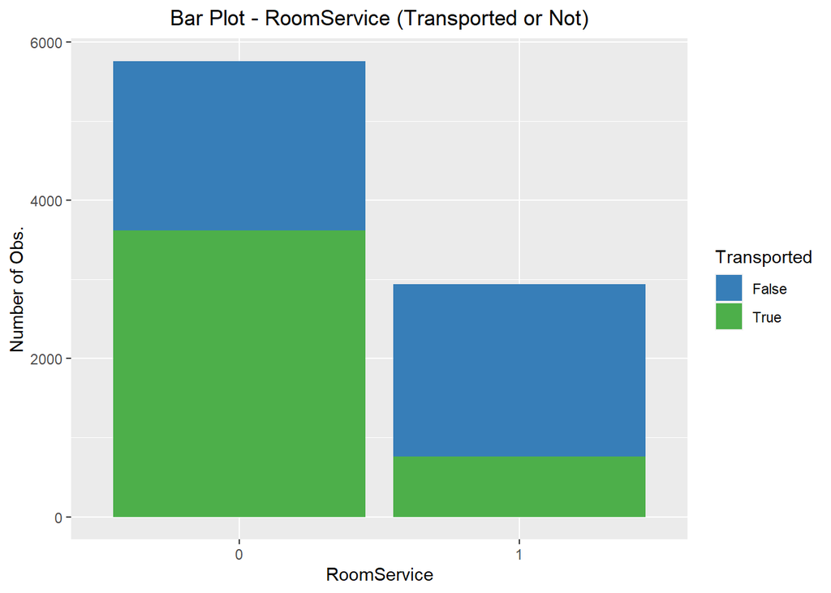

```r
ggplot(train_x, aes(RoomService, fill = Transported)) +
  geom_bar() +
  scale_fill_manual(values = my_colors, labels = c('False', 'True')) +
  ggtitle('Bar Plot - RoomService (Transported or Not)') + theme(plot.title = element_text(hjust = 0.5)) +
  ylab('Number of Obs.')
```

FoodCourt

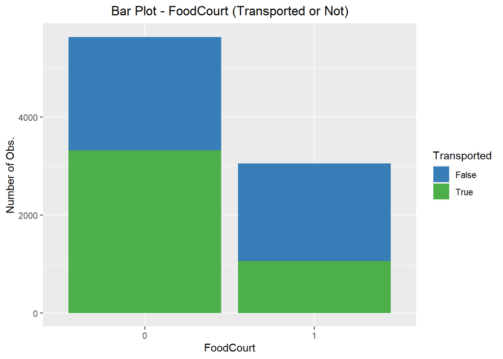

```r
ggplot(train_x, aes(FoodCourt, fill = Transported)) +
  geom_bar() +
  scale_fill_manual(values = my_colors, labels = c('False', 'True')) +
  ggtitle('Bar Plot - FoodCourt (Transported or Not)') + theme(plot.title = element_text(hjust = 0.5)) +
  ylab('Number of Obs.')
```

ShoppingMall

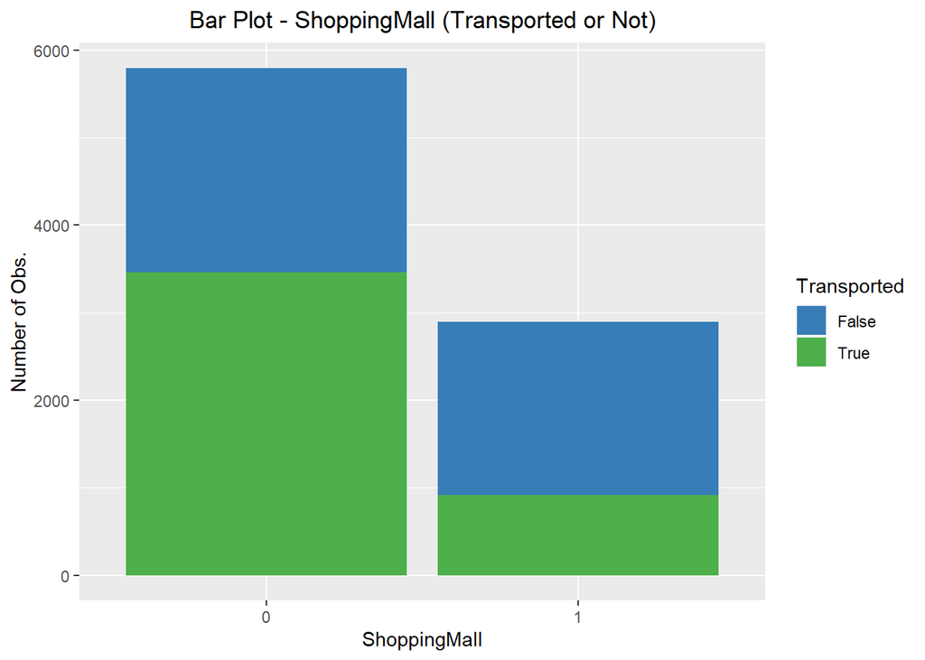

```r
ggplot(train_x, aes(ShoppingMall, fill = Transported)) +
  geom_bar() +
  scale_fill_manual(values = my_colors, labels = c('False', 'True')) +
  ggtitle('Bar Plot - ShoppingMall (Transported or Not)') + theme(plot.title = element_text(hjust = 0.5)) +
  ylab('Number of Obs.')
```

Spa

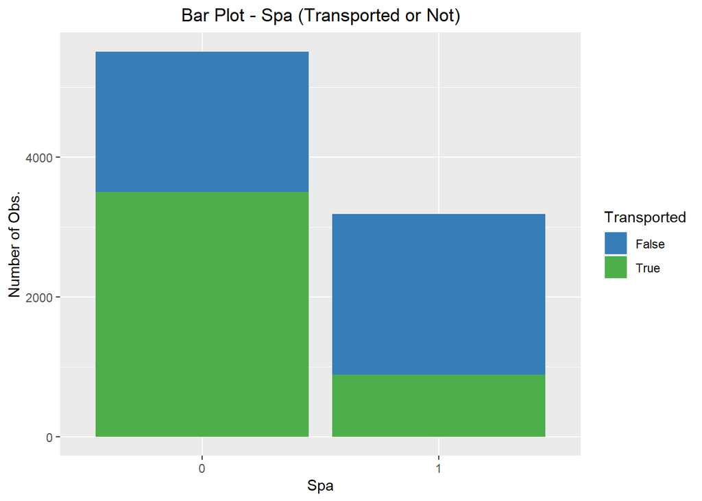

```r
ggplot(train_x, aes(Spa, fill = Transported)) +
  geom_bar() +
  scale_fill_manual(values = my_colors, labels = c('False', 'True')) +
  ggtitle('Bar Plot - Spa (Transported or Not)') + theme(plot.title = element_text(hjust = 0.5)) +
  ylab('Number of Obs.')
```

VRDeck

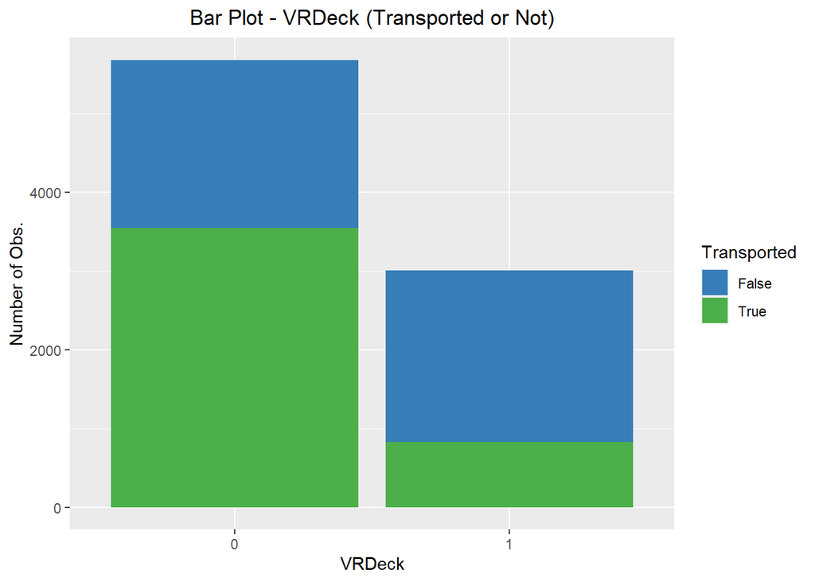

```r
ggplot(train_x, aes(VRDeck, fill = Transported)) +
  geom_bar() +
  scale_fill_manual(values = my_colors, labels = c('False', 'True')) +
  ggtitle('Bar Plot - VRDeck (Transported or Not)') + theme(plot.title = element_text(hjust = 0.5)) +
  ylab('Number of Obs.')
```

Age

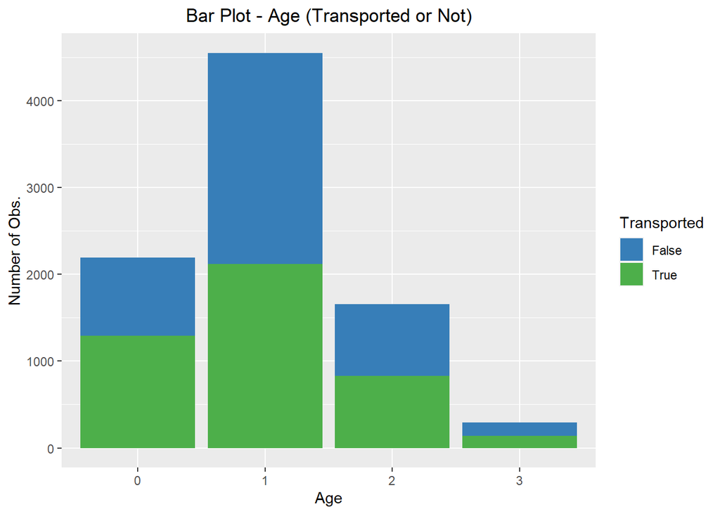

```r
ggplot(train_x, aes(Age, fill = Transported)) +
  geom_bar() +
  scale_fill_manual(values = my_colors, labels = c('False', 'True')) +
  ggtitle('Bar Plot - Age (Transported or Not)') + theme(plot.title = element_text(hjust = 0.5)) +
  ylab('Number of Obs.')
```

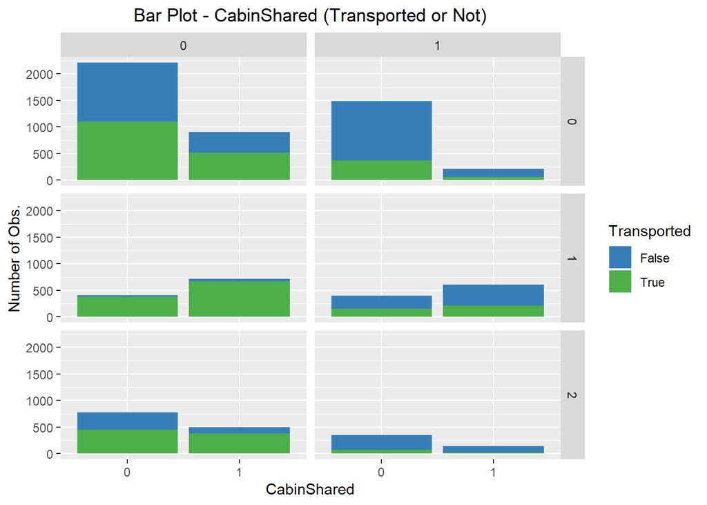

```r
ggplot(train_x, aes(CabinShared, fill = Transported)) +
  geom_bar() +
  scale_fill_manual(values = my_colors, labels = c('False', 'True')) +
  ggtitle('Bar Plot - CabinShared (Transported or Not)') + theme(plot.title = element_text(hjust = 0.5)) +
  ylab('Number of Obs.') +
  scale_y_continuous(breaks = seq(0, 5000, by = 500)) +
  facet_grid(rows = vars(HomePlanet), cols = vars(Spa))
```

- Plot above: Left side = Passengers who didn’t went to Spa; and right side = Passengers who went to Spa. We clearly see that passengers that paid a service in the ship did more chance to survive. If we plot ShoppingMall or whatever other service, we’ll see almost the same plot.  
  Columns  
  0 = Cabin not shared.  
  1 = Cabin shared.  
  Rows  
  0 = Home Planet Earth  
  1 = Home Planet Europa  
  2 = Home Planet Mars

### Tables of Former Numeric Columns

**RoomService**

```r
ctable(train_x$RoomService, train_x$Transported,  dnn = c('RoomService', 'Transported'))
```

```
## Cross-Tabulation, Row Proportions
## RoomService * Transported
## Data Frame: train_x
##
## ------------- ------------- -------------- -------------- ---------------
##                 Transported              0              1           Total
##   RoomService
##             0                 2143 (37.2%)   3615 (62.8%)   5758 (100.0%)
##             1                 2172 (74.0%)    763 (26.0%)   2935 (100.0%)
##         Total                 4315 (49.6%)   4378 (50.4%)   8693 (100.0%)
## ------------- ------------- -------------- -------------- ---------------
```

While 62.8% of the passengers that didn’t had any spend in the trip were Transported, 37.2% weren’t. The opposite happens when the passenger spend some amount. 74% of the passengers with some amount of spending were not Transported, and 26% of the passenger that spend any amount were Transported. The premise is the same with the other services, but of course, with different values.

**FoodCourt**

```r
ctable(train_x$FoodCourt, train_x$Transported,  dnn = c('FoodCourt', 'Transported'))
```

```
## Cross-Tabulation, Row Proportions
## FoodCourt * Transported
## Data Frame: train_x
##
## ----------- ------------- -------------- -------------- ---------------
##               Transported              0              1           Total
##   FoodCourt
##           0                 2316 (41.1%)   3323 (58.9%)   5639 (100.0%)
##           1                 1999 (65.5%)   1055 (34.5%)   3054 (100.0%)
##       Total                 4315 (49.6%)   4378 (50.4%)   8693 (100.0%)
## ----------- ------------- -------------- -------------- ---------------
```

**ShoppingMall**

```r
ctable(train_x$ShoppingMall, train_x$Transported,  dnn = c('ShoppingMall', 'Transported'))
```

```
## Cross-Tabulation, Row Proportions
## ShoppingMall * Transported
## Data Frame: train_x
##
## -------------- ------------- -------------- -------------- ---------------
##                  Transported              0              1           Total
##   ShoppingMall
##              0                 2336 (40.3%)   3459 (59.7%)   5795 (100.0%)
##              1                 1979 (68.3%)    919 (31.7%)   2898 (100.0%)
##          Total                 4315 (49.6%)   4378 (50.4%)   8693 (100.0%)
## -------------- ------------- -------------- -------------- ---------------
```

**Spa**

```r
ctable(train_x$Spa, train_x$Transported,  dnn = c('Spa', 'Transported'))
```

```
## Cross-Tabulation, Row Proportions
## Spa * Transported
## Data Frame: train_x
##
## ------- ------------- -------------- -------------- ---------------
##           Transported              0              1           Total
##     Spa
##       0                 2013 (36.6%)   3494 (63.4%)   5507 (100.0%)
##       1                 2302 (72.3%)    884 (27.7%)   3186 (100.0%)
##   Total                 4315 (49.6%)   4378 (50.4%)   8693 (100.0%)
## ------- ------------- -------------- -------------- ---------------
```

**VRDeck**

```r
ctable(train_x$VRDeck, train_x$Transported,  dnn = c('VRDeck', 'Transported'))
```

```
## Cross-Tabulation, Row Proportions
## VRDeck * Transported
## Data Frame: train_x
##
## -------- ------------- -------------- -------------- ---------------
##            Transported              0              1           Total
##   VRDeck
##        0                 2134 (37.6%)   3549 (62.4%)   5683 (100.0%)
##        1                 2181 (72.5%)    829 (27.5%)   3010 (100.0%)
##    Total                 4315 (49.6%)   4378 (50.4%)   8693 (100.0%)
## -------- ------------- -------------- -------------- ---------------
```

**Age**

```r
ctable(train_x$Age, train_x$Transported,  dnn = c('Age', 'Transported'))
```

```
## Cross-Tabulation, Row Proportions
## Age * Transported
## Data Frame: train_x
##
## ------- ------------- -------------- -------------- ---------------
##           Transported              0              1           Total
##     Age
##       0                  902 (41.1%)   1293 (58.9%)   2195 (100.0%)
##       1                 2433 (53.5%)   2117 (46.5%)   4550 (100.0%)
##       2                  823 (49.8%)    830 (50.2%)   1653 (100.0%)
##       3                  157 (53.2%)    138 (46.8%)    295 (100.0%)
##   Total                 4315 (49.6%)   4378 (50.4%)   8693 (100.0%)
## ------- ------------- -------------- -------------- ---------------
```

## Make the Predictions

Setting a seed first.

```r
set.seed(10)
```

### Split

```r
sample = sample.split(train_x$Transported, SplitRatio = 0.7)
train_X = subset(train_x, sample == T)
test_X = subset(train_x, sample == F)
```

### Logistic Regression

```r
log.fit = glm(Transported~., data = train_X, family = 'binomial')
prob.log = predict(log.fit, type = 'response', newdata = test_X)
pred.log = ifelse(prob.log > 0.5, 1, 0) %>% as.factor()
matrix.log = table(test_X$Transported, pred.log)
matrix.log
```

```
##    pred.log
##        0    1
##   0 1004  291
##   1  382  931
```

**Accuracy**

```r
acc.log = (matrix.log[1, 1] + matrix.log[2, 2]) / (matrix.log[1, 1] + matrix.log[1, 2] + matrix.log[2, 1] + matrix.log[2, 2])
acc.log
```

```
## [1] 0.7419479
```

### SVM - Linear Kernel

```r
svm.fit = svm(Transported ~ ., data = train_X, type = 'C-classification', kernel = 'linear')
pred.svm = predict(svm.fit, newdata = test_X)
matrix.svm = table(test_X$Transported, pred.svm)
matrix.svm
```

```
##    pred.svm
##        0    1
##   0 1131  164
##   1  568  745
```

**Accuracy**

```r
acc.svm = (matrix.svm[1, 1] + matrix.svm[2, 2]) / (matrix.svm[1, 1] + matrix.svm[1, 2] + matrix.svm[2, 1] + matrix.svm[2, 2])
acc.svm
```

```
## [1] 0.7193252
```

### SVM - Radial Kernel

```r
svm.fit2 = svm(Transported ~ ., data = train_X, type = 'C-classification', kernel = 'radial')
pred.svm2 = predict(svm.fit2, newdata = test_X)
matrix.svm2 = table(test_X$Transported, pred.svm2)
matrix.svm2
```

```
##    pred.svm2
##        0    1
##   0 1068  227
##   1  454  859
```

**Accuracy**

```r
acc.svm2 = (matrix.svm2[1, 1] + matrix.svm2[2, 2]) / (matrix.svm2[1, 1] + matrix.svm2[1, 2] + matrix.svm2[2, 1] + matrix.svm2[2, 2])
acc.svm2
```

```
## [1] 0.7388804
```

### Naive Bayes

```r
nb.fit = naiveBayes(x = train_X[, -11],
                    y = train_X$Transported)
pred.nb = predict(nb.fit, newdata = test_X)
matrix.nb = table(test_X$Transported, pred.nb)
matrix.nb
```

```
##    pred.nb
##        0    1
##   0 1039  256
##   1  428  885
```

**Accuracy**

```r
acc.nb = (matrix.nb[1, 1] + matrix.nb[2, 2]) / (matrix.nb[1, 1] + matrix.nb[1, 2] + matrix.nb[2, 1] + matrix.nb[2, 2])
acc.nb
```

```
## [1] 0.7377301
```

### K-NN

```r
knn.fit = knn(train = train_X[, -11],
              test = test_X[, -11],
              cl = train_X[, 11],
              k = 5)
matrix.knn = table(test_X$Transported, knn.fit)
matrix.knn
```

```
##    knn.fit
##        0    1
##   0 1015  280
##   1  425  888
```

**Accuracy**

```r
acc.knn = (matrix.knn[1, 1] + matrix.knn[2, 2]) / (matrix.knn[1, 1] + matrix.knn[1, 2] + matrix.knn[2, 1] + matrix.knn[2, 2])
acc.knn
```

```
## [1] 0.7296779
```

### Decision Tree

```r
dt.fit = rpart(Transported ~., data = train_X)
pred.dt = predict(dt.fit, newdata = test_X, type = 'class') %>% as.factor()
matrix.dt = table(test_X$Transported, pred.dt)
matrix.dt
```

```
##    pred.dt
##        0    1
##   0 1041  254
##   1  424  889
```

**Accuracy**

```r
acc.dt = (matrix.dt[1, 1] + matrix.dt[2, 2]) / (matrix.dt[1, 1] + matrix.dt[1, 2] + matrix.dt[2, 1] + matrix.dt[2, 2])
acc.dt
```

```
## [1] 0.7400307
```

### Random Forest

```r
rf.fit = randomForest(x = train_X[, -11], y = train_X$Transported, ntree = 300)
pred.rf = predict(rf.fit, newdata = test_X)
matrix.rf = table(test_X$Transported, pred.rf)
matrix.rf
```

```
##    pred.rf
##        0    1
##   0 1041  254
##   1  405  908
```

**Accuracy**

```r
acc.rf = (matrix.rf[1, 1] + matrix.rf[2, 2]) / (matrix.rf[1, 1] + matrix.rf[1, 2] + matrix.rf[2, 1] + matrix.rf[2, 2])
acc.rf
```

```
## [1] 0.747316
```

### DataFrame

```r
Accuracy = data.frame(Model = c('Logistic Regression', 'SVM - Linear', 'SVM - Radial', 'Naive Bayes', 'K-NN', 'Decision Tree', 'Random Forest'),
                      Accuracy = c(acc.log, acc.svm, acc.svm2, acc.nb, acc.knn, acc.rf, acc.dt))

Accuracy
```

```
##                 Model  Accuracy
## 1 Logistic Regression 0.7419479
## 2        SVM - Linear 0.7193252
## 3        SVM - Radial 0.7388804
## 4         Naive Bayes 0.7377301
## 5                K-NN 0.7296779
## 6       Decision Tree 0.7473160
## 7       Random Forest 0.7400307
```

### Deep Learning - ANN

```r
h2o.init(nthreads = -1)
```

```
##  Connection successful!
##
## R is connected to the H2O cluster:
##     H2O cluster uptime:         34 minutes 27 seconds
##     H2O cluster timezone:       America/Sao_Paulo
##     H2O data parsing timezone:  UTC
##     H2O cluster version:        3.38.0.1
##     H2O cluster version age:    1 month and 13 days
##     H2O cluster name:           H2O_started_from_R_sunse_ckp777
##     H2O cluster total nodes:    1
##     H2O cluster total memory:   1.95 GB
##     H2O cluster total cores:    4
##     H2O cluster allowed cores:  4
##     H2O cluster healthy:        TRUE
##     H2O Connection ip:          localhost
##     H2O Connection port:        54321
##     H2O Connection proxy:       NA
##     H2O Internal Security:      FALSE
##     R Version:                  R version 4.2.1 (2022-06-23 ucrt)
```

```r
ann.fit = h2o.deeplearning(y = 'Transported', training_frame = as.h2o(train_X),
                              activation = 'TanhWithDropout', hidden = c(7, 7),
                              epochs = 5, train_samples_per_iteration = -2)
prob.ann = h2o.predict(ann.fit, newdata = as.h2o(test_X))
pred.ann = prob.ann$predict %>% as.vector
matrix.ann = table(test_X$Transported, pred.ann)
matrix.ann
```

```
##    pred.ann
##       0   1
##   0 924 371
##   1 342 971
```

```r
acc.ann = (matrix.ann[1, 1] + matrix.ann[2, 2]) / (matrix.ann[1, 1] + matrix.ann[1, 2] + matrix.ann[2, 1] + matrix.ann[2, 2])
acc.ann
```

```
## [1] 0.7266104
```

### K-Fold Cross Validation

I’ll make K-Fold CV only for the SVM.

```r
folds = createFolds(train_X$Transported, k = 10)
cv = lapply(folds, function(x) {
  train_fold = train_X[-x, ]
  test_fold = train_X[x, ]
  svm.fit1 = svm(Transported ~., data = train_fold,
                type = "C-classification",
                kernel = "radial")
  svm_pred1 = predict(svm.fit1, newdata = test_fold)
  svm_Matrix1 = (confusionMatrix(svm_pred1, test_fold$Transported)$overall['Accuracy'])
})

mean(as.numeric(cv))
```

```
## [1] 0.7406701
```

```r
h2o.shutdown()
```

```
## Are you sure you want to shutdown the H2O instance running at http://localhost:54321/ (Y/N)?
```